# Layout’s

Viendo las posibilidades de Layout que tenemos en Quarto

quarto

layout

Autor

Afiliación

[Pedro J. Pérez](https://www.uv.es/pjperez/)

[Universitat de València](https://www.uv.es)

Fecha de Publicación

21 de enero de 2023

Fecha de modificación

17 de mayo de 2024

## 1 Intro

Además de yaml, texto y chunks, para escribir con Quarto **conviene conocer la estructura o layout de los artículos** que se generan con él. Las páginas tienen un body, un margin y un área para las sidebars, que en nuestro caso contiene un TOC[^1]. Documentación oficial [aquí](https://quarto.org/docs/authoring/article-layout.html) y [aquí](https://quarto.org/docs/output-formats/page-layout.html#grid-customization). Además, desde Quarto 1.3 podemos redimensionar los elementos de nuestras webs y documentos .html, para, por ejemplo, dar más espacio a la sidebar o al margin: documentación [aquí](https://quarto.org/docs/output-formats/page-layout.html#grid-customization).

Además, usando [divs y spans](https://quarto.org/docs/authoring/markdown-basics.html#divs-and-spans) podemos añadir clases y atributos, haciendo que determinados elementos de nuestro documento cambien sus “propiedades”. En esta sección usaremos divs para hacer que determinadas partes de nuestro post se ajusten a distintos layout’s y ocupen más o menos espacio en nuestros documentos.

## 2 Ejemplo (con imágenes)

Para ver las distintas posibilidades que tenemos, **insertaremos una imagen** ocupando distintas áreas del artículo. Empezaremos situando la imagen en el margen. para ello habría que hacer lo siguiente:

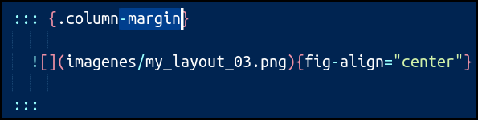

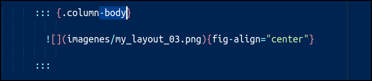

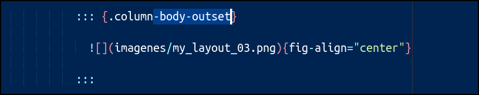

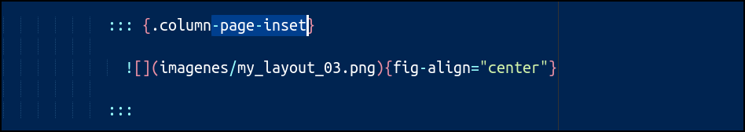

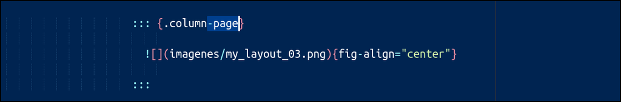

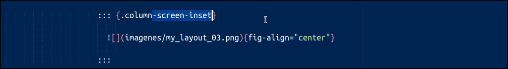

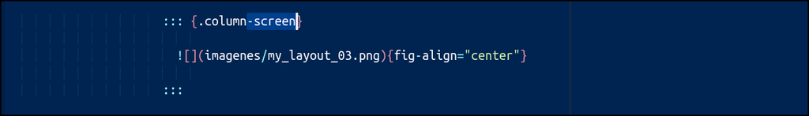

```yaml
::: {.column-margin}

![](imagenes/post_21_img_01.png){fig-align="center"}

:::
```

Si queremos podemos llegar a ocupar el 100% de la pantalla. Sólo habría que indicarlo en las opciones de la imagen con `width="100%"`.

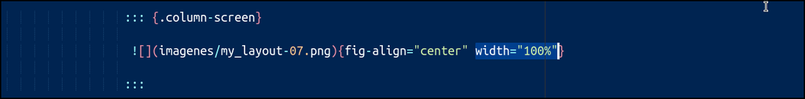

## 3 Ejemplo (con chunks)

El output de los chunks también puede ocupar distintas áreas. Veamos si un leaflet se puede poner en el margen:

**Código**

````markdown
```{r}
#| column: margin
#| eval: true
library(leaflet)
leaflet() %>%
  addTiles() %>%  # Add default OpenStreetMap map tiles
  addMarkers(lng = -4.7880, lat = 37.885, popup = "Rectorado de la Universidad de Córdoba\n (Sede de las XII Jornadas de usuarios de R)")
```
````

[interactive chart not shown]

Y ahora ocupando toda la pantalla:

**Código**

````markdown
```{r}
#| column: screen
#| eval: true
library(leaflet)
leaflet() %>%
  addTiles() %>%  # Add default OpenStreetMap map tiles
addMarkers(lng = -4.7880, lat = 37.885, popup = "Rectorado de la Universidad de Córdoba\n (Sede de las XII Jornadas de usuarios de R)")
```
````

[interactive chart not shown]

Como no puede ser de otro modo, aún hay más opciones para el layout. Documentación [aquí](https://quarto.org/docs/authoring/article-layout.html#overflowing-content)

## 4 Layout de las páginas

Además, para el layout de toda la página tienes las opciones [aquí](https://quarto.org/docs/output-formats/page-layout.html#overview). Si quieres crear un “custom layout” quizás tengas que usar [Bootstrap CSS grid](https://getbootstrap.com/docs/5.1/layout/css-grid/).

## Notas

[^1]: Además, el layout puede venir afectado por la opción `page-layout: custom #- {article, full, custom}`. Documentación oficial [aquí](https://quarto.org/docs/output-formats/page-layout.html)